# Fun With the R Grid Package

## 1.2 Using Viewports to Display Data

The data set:

```r
escape_prop <- c(0.24, 0.28, 0.28, 0.33, 0.33, 0.32, 0.30, 0.21, 0.30, 0.28,
                 0.17, 0.27, 0.21, 0.18, 0.22, 0.21, 0.19, 0.17, 0.17, 0.15,
                 0.25, 0.19, 0.19, 0.22, 0.21, 0.18, 0.24, 0.23, 0.27, 0.16,
                 0.17, 0.22, 0.17, 0.25, 0.19, 0.25, 0.12, 0.17, 0.22, 0.22)
nfires <- c(953, 620, 584, 839, 1415, 1180, 656, 408, 872, 965,
            853, 1492, 951, 772, 1541, 1114, 479, 860, 1166, 1208,
            657, 1140,1223, 1275, 489, 932, 1096, 1378, 1033, 889,
            1046, 818, 1213,782, 962, 1666, 2017, 1689, 1885, 1435)
nfires_scaled <- nfires/max(nfires)
index <- (1:40)/41
```

Task: Plot the fire data using *grid*.

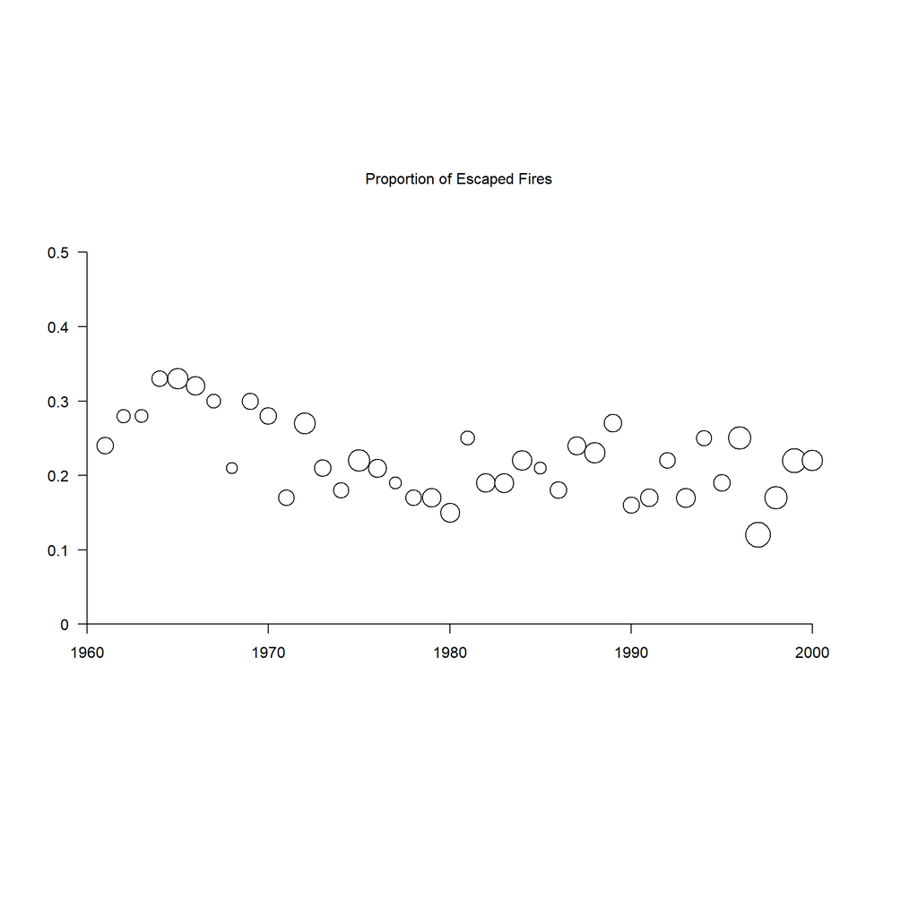

```r
grid::grid.newpage()
grid::pushViewport(viewport(width = .9, height = .9))
grid::pushViewport(viewport(y=0.75, width = .9, height = .9))
for(i in 1:40){
  vp <- viewport(x=index[i], y = escape_prop[i], height = 0.03, width = 0.03)
  grid::pushViewport(vp)
  grid::grid.circle(r = sqrt(nfires_scaled[i]/pi))
  grid::upViewport()
}
grid::grid.xaxis(at = c(0, index[c(10,20,30,40)]), label = seq(1960,2000,10))
grid::grid.yaxis(at=seq(0,0.5,0.1))
grid::grid.text("Proportion of Escaped Fires", y = 0.6)
```

## 1.3 Graphics Objects and Editing

An important feature of grid graphics is the graphical object (also called a *grob*). There are two ways to interact with a grob: 1. Drawing it immediately – `grid::grid.rect()` creates a grob and draws it 2. Create it but don’t draw – `grid::rectGrob()` creates a grob but does not draw it; to draw it use `grid::grid.draw()`

Modify a grob by using `grid::grid.edit()` and `grid::editGrob()`

Task: Create and edit some rectangle grobs.

1. Create but don’t draw a rectangle and name it “gr_rect_1”

```r
gr_rect_1 <- grid::rectGrob(width = 0.1, height = 0.1, name = "gr_rect_1") #note: x = 0.5, y = 0.5 by default
```

2. Using `grid::editGrob()` copy “gr_rect_1” centered at (0.2, 0.6) and draw it

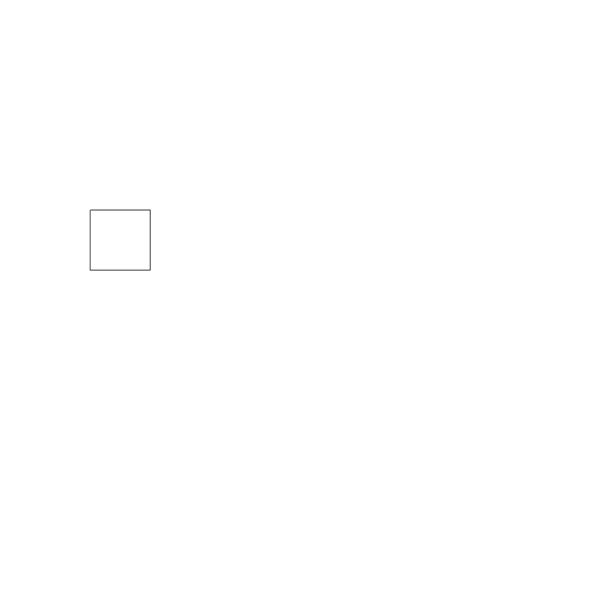

```r
grid::grid.newpage()
gr_copy_1 <- grid::editGrob(grob = gr_rect_1, vp = viewport(x = 0.2, y = 0.6), name = "gr_copy_1")
grid::grid.draw(gr_copy_1)
```

3. Create and draw a second copy centered at (0.7, 0.75:

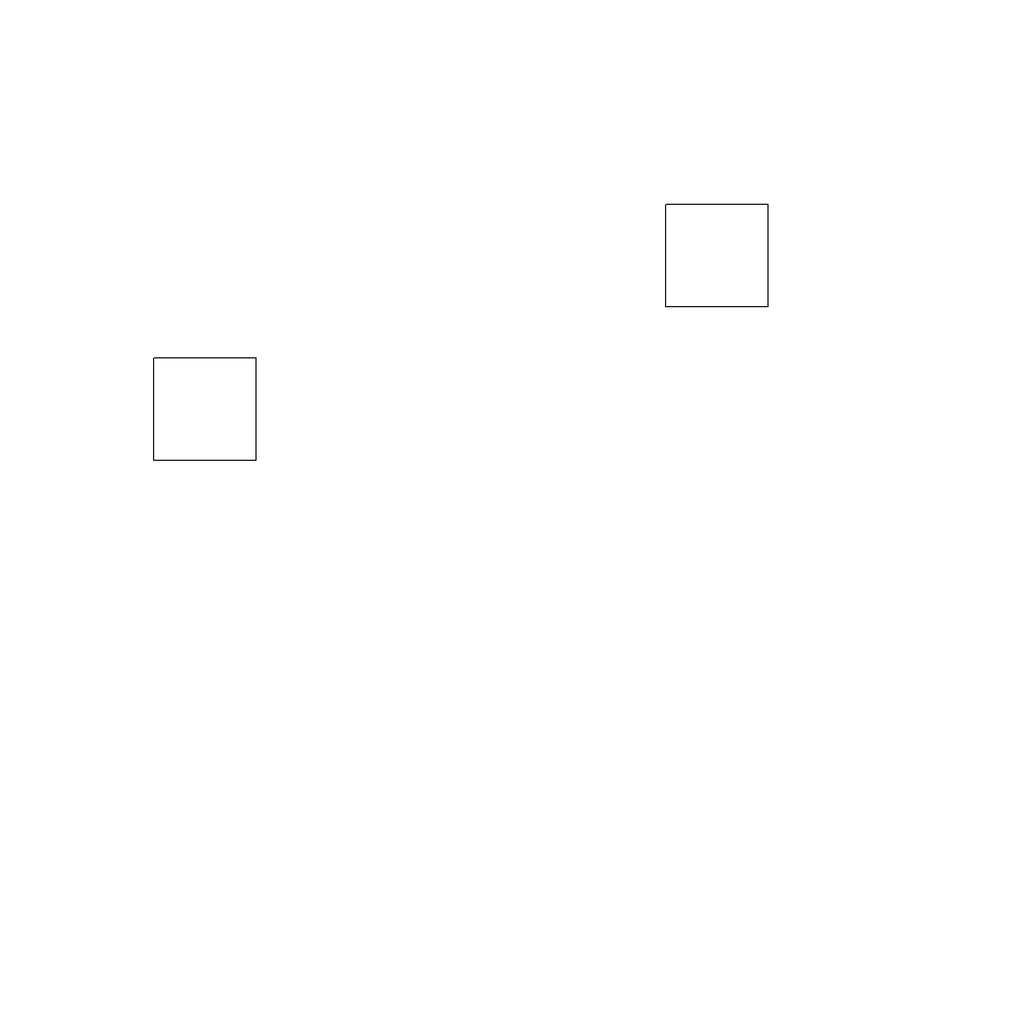

```r
grid::grid.newpage()
gr_copy_2 <- grid::editGrob(grob = gr_rect_1, vp = viewport(x = 0.7, y = 0.75), name = "gr_copy_2")
grid::grid.draw(gr_copy_1)
grid::grid.draw(gr_copy_2)
```

3. Create and draw a third copy centered at (0.5, 0.4:

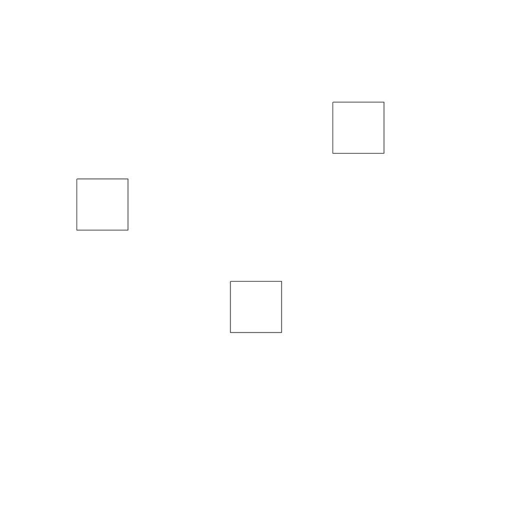

```r
grid::grid.newpage()
gr_copy_3 <- grid::editGrob(grob = gr_rect_1, vp = viewport(x = 0.5, y = 0.4), name = "gr_copy_3")
grid::grid.draw(gr_copy_1)
grid::grid.draw(gr_copy_2)
grid::grid.draw(gr_copy_3)
```

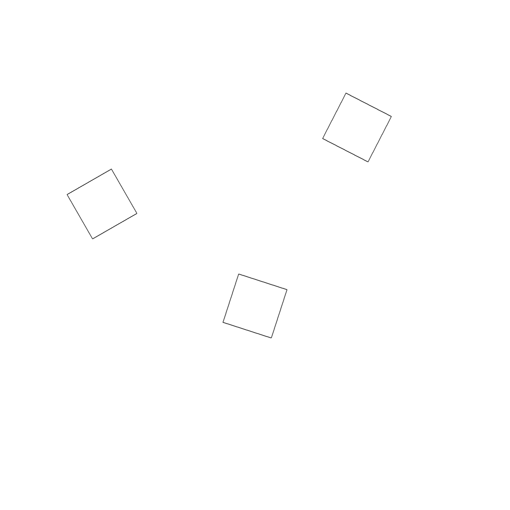

```r
grid::grid.newpage()
gr_copy_1 <- grid::editGrob(grob = gr_copy_1, vp = viewport(x = 0.2, y = 0.6, angle = 30))
gr_copy_2 <- grid::editGrob(grob = gr_copy_2, vp = viewport(x = 0.7, y = 0.75, angle = 63))
gr_copy_3 <- grid::editGrob(grob = gr_copy_3, vp = viewport(x = 0.5, y = 0.4, angle = 72))
grid::grid.draw(gr_copy_1)
grid::grid.draw(gr_copy_2)
grid::grid.draw(gr_copy_3)
```

Task: Create a function `draw_star()` for drawing a single star.

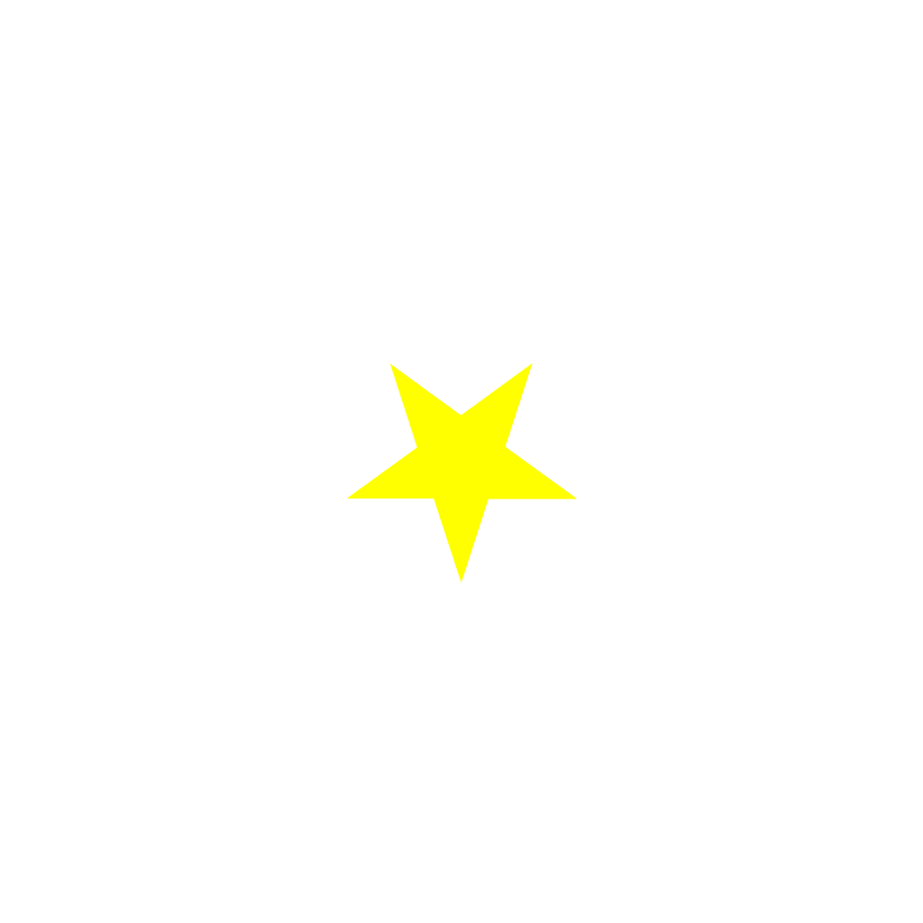

```r
draw_star <- function(x = 0.5, y = 0.5, width = 0.25, height = 0.25, angle = 0, name = "a_star", fill = "purple"){
  grid::pushViewport(vp = viewport(x = x, y = y, width = width, height = height, angle = angle, name = name))
  b2 <- sqrt(1/cos(36 * pi/180)^2-1)/2
  b3 <- sin(72*pi/180)/(2*(1+cos(72*pi/180))) - (1-sin(72*pi/180))/2
  a_triangle <- grid::polygonGrob(c(0, 0.5,1), c(b3, b2+b3, b3),
                                  gp = gpar(fill = fill,
                                  col = 0)
                                 )
  for(i in 0:2){
    grid::pushViewport(vp = viewport(angle = 72 * i, name = paste0("triangle_",i)))
    grid::grid.draw(a_triangle)
    grid::upViewport()
  }
  grid::upViewport()
}
grid.newpage()
draw_star(name = "star_1", fill = "yellow")
```

```r
grid.ls(viewports = TRUE)
```

```
## ROOT
##   star_1
##     triangle_0
##       GRID.polygon.114
##       1
##     triangle_1
##       GRID.polygon.114
##       1
##     triangle_2
##       GRID.polygon.114
##       1
##     1
```

Task: Create rotated and scaled stars on a blue background.

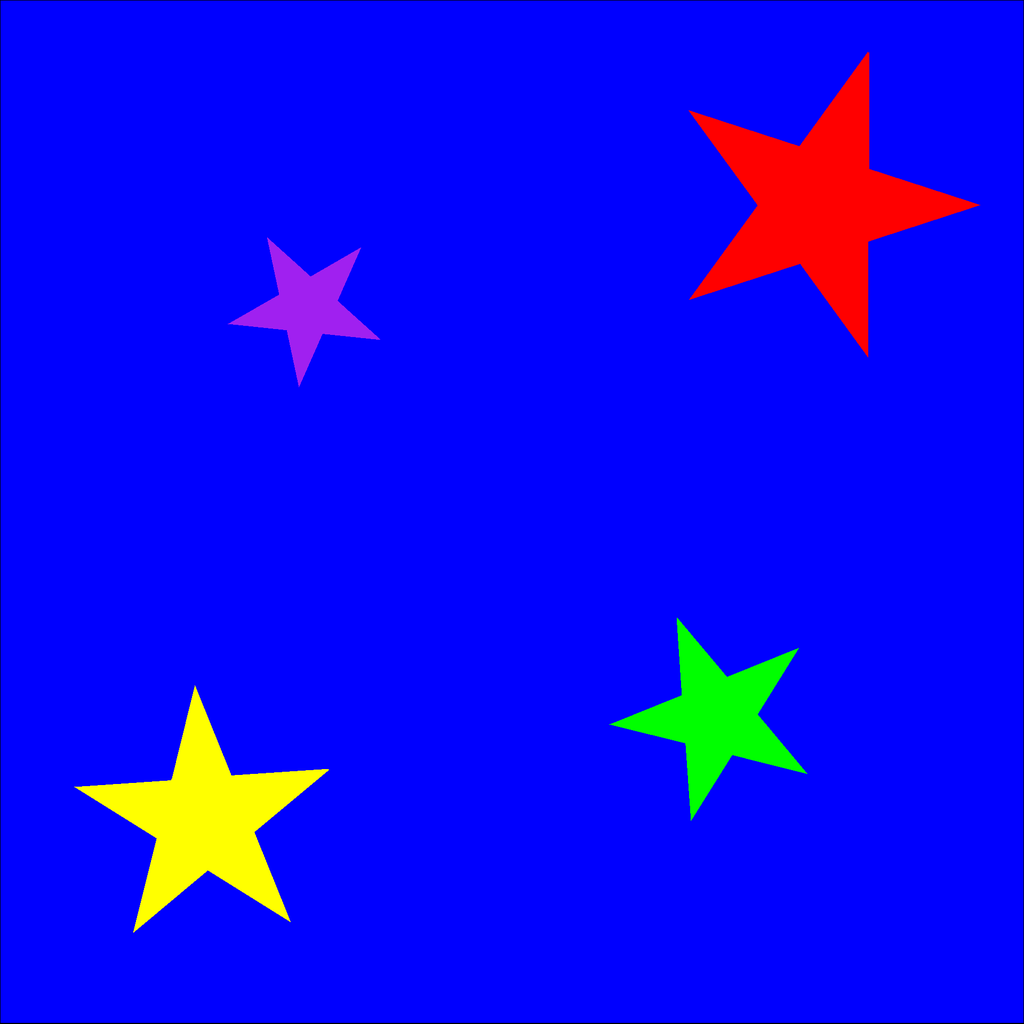

```r
grid::grid.newpage()
# create the background viewport
grid::grid.rect(gp = gpar(fill = "blue"))

#draw star 1
draw_star(x=0.2, y=0.2, width = 0.25, height = 0.25, angle = 40, fill = "yellow", name = "star_1")

#draw star 2
draw_star(x=0.8, y=0.8, width = 0.3, height = 0.3, angle = 90, fill = "red", name = "star_2")

#draw star 3
draw_star(x=0.7, y=0.3, width = 0.2, height = 0.2, angle = 130, fill = "green", name = "star_3")

#draw star 4
draw_star(x=0.3, y=0.7, width = 0.15, height = 0.15, angle = 210, fill = "purple", name = "star_4")
```

## 1.4 gTree and gList

The function `grid::gList()` allows us to create a grob that contains a list of grobs.

Task: Redefine the above function `draw_star()` to `create_star()` that returns a single grob containing a list of triangle grobs.

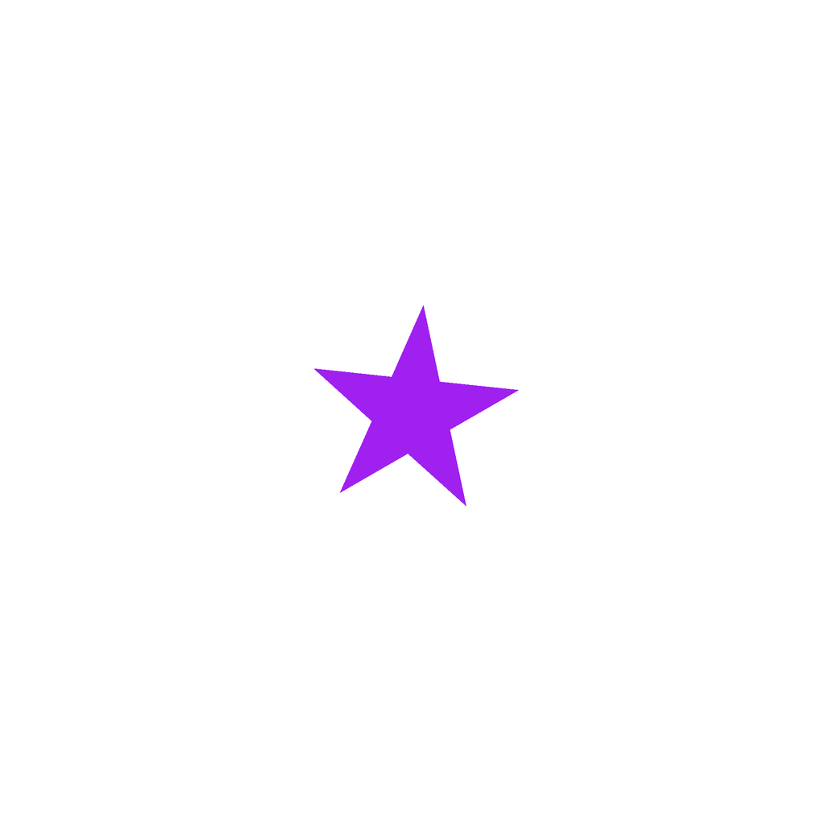

```r
create_star <- function(x = 0.5, y = 0.5, width = 0.25, height = 0.25, angle = 0, name = "a_star", fill = "purple") {
  b2 <- sqrt(1/cos(36 * pi/180)^2-1)/2
  b3 <- sin(72*pi/180)/(2*(1+cos(72*pi/180))) - (1-sin(72*pi/180))/2

  starGrobs <- grid::gList(
    grid::polygonGrob(
      x = c(0, 0.5,1),
      y = c(b3, b2+b3, b3),
      gp = grid::gpar(fill = fill, col = 0),
      vp = grid::viewport(angle = 0, name = paste0("triangle_",0))
    ),
    grid::polygonGrob(
      x = c(0, 0.5,1),
      y = c(b3, b2+b3, b3),
      gp = grid::gpar(fill = fill, col = 0),
      vp = grid::viewport(angle = 72, name = paste0("triangle_",1))
    ),
    grid::polygonGrob(
      x = c(0, 0.5,1),
      y = c(b3, b2+b3, b3),
      gp = grid::gpar(fill = fill, col = 0),
      vp = grid::viewport(angle = 144, name = paste0("triangle_",2))
    )
  )
  starTree <- grid::gTree(children = starGrobs, name = name, vp = grid::viewport(x = x, y = y, width = width, height = height, angle = angle))

  return(starTree)
}

starTree <- create_star(x = .5, y = .5, width = 0.25, height = 0.25, angle = 30)
grid::grid.newpage()
grid::grid.draw(starTree)
```

## 1.5 Other Scales

*native* - locations and sizes are relative to the x and y scales for the current viewport *npc* (the default) - Normalized Parent Coordinates. Treats the bottom left corner of the current viewport as the location of (0,0) and top right as (1,1).

Other scales: cm, inches, mm, points, lines